# act_report

### WeRateDog Analysis Act Report

**This report is the summary of the data analysis process of this data wrangling project.**

In this project, I made use of three different datasets that were obtained using three different methods.

- The first dataset was provided by Udacity named `twitter_archive_enhanced.csv` and it was downloaded manually and saved as `twitter_df`. It contained basic information about `2356` tweets.
- The second dataset was a tsv file named `image_predictions.tsv` which was already hosted on Udacity's servers.Then, I downloaded programmatically using python's requests and os libraries. I read it into a pandas dataframe named as `imagepre_df`. It contained `2075` predictions made by a neural network that can classify dog breeds.
- The third dataset was a `tweet-json.txt` file which I downloaded and then read the file line by line to obtain basic information such as tweets, favorite count, retweet count which were a total of `2354`.

While assessing, I detected 8 quality issues and 2 tidiness issues which I cleaned using variety of python and pandas methods.

After gathering, assessing and cleaning, I saved the master dataset as a csv file named `twitter_archive_master.csv`.

**Here are the insights and visualizations I obtained after analyses.**

First, I imported the pandas library and loaded the master dataset.

```python
import pandas as pd
df= pd.read_csv('twitter_archive_master.csv')
```

```python
df.head()
```

|  | tweet_id | timestamp | source | text | rating_numerator | rating_denominator | name | dog_stages | favorite_count | retweet_count | tweets |
| --- | --- | --- | --- | --- | --- | --- | --- | --- | --- | --- | --- |
| 0 | 890240255349198849 | 2017-07-26 15:59:51 | Twitter for iPhone | This is Cassie. She is a college pup. Studying... | 14 | 10 | Cassie | doggo | 32467.0 | 7711.0 | {'created_at': 'Wed Jul 26 15:59:51 +0000 2017... |
| 1 | 884162670584377345 | 2017-07-09 21:29:42 | Twitter for iPhone | Meet Yogi. He doesn't have any important dog m... | 12 | 10 | Yogi | doggo | 20771.0 | 3128.0 | {'created_at': 'Sun Jul 09 21:29:42 +0000 2017... |
| 2 | 872967104147763200 | 2017-06-09 00:02:31 | Twitter for iPhone | Here's a very large dog. He has a date later. ... | 12 | 10 | None | doggo | 28031.0 | 5669.0 | {'created_at': 'Fri Jun 09 00:02:31 +0000 2017... |
| 3 | 871515927908634625 | 2017-06-04 23:56:03 | Twitter for iPhone | This is Napolean. He's a Raggedy East Nicaragu... | 12 | 10 | Napolean | doggo | 20730.0 | 3628.0 | {'created_at': 'Sun Jun 04 23:56:03 +0000 2017... |
| 4 | 871102520638267392 | 2017-06-03 20:33:19 | Twitter for iPhone | Never doubt a doggo 14/10 https://t.co/AbBLh2FZCH | 14 | 10 | None | doggo | 21461.0 | 5764.0 | {'created_at': 'Sat Jun 03 20:33:19 +0000 2017... |

Then using the describe function, I got more information about the dataset.

```python
df.describe()
```

|  | tweet_id | rating_numerator | rating_denominator | favorite_count | retweet_count |
| --- | --- | --- | --- | --- | --- |
| count | 2.347000e+03 | 2347.000000 | 2347.0 | 2345.000000 | 2345.000000 |
| mean | 7.431992e+17 | 12.232211 | 10.0 | 8141.895522 | 3189.313433 |
| std | 6.863351e+16 | 40.900209 | 0.0 | 11873.823039 | 5309.440551 |
| min | 6.660209e+17 | 0.000000 | 10.0 | 0.000000 | 0.000000 |
| 25% | 6.784049e+17 | 10.000000 | 10.0 | 1415.000000 | 631.000000 |
| 50% | 7.210012e+17 | 11.000000 | 10.0 | 3627.000000 | 1489.000000 |
| 75% | 8.000798e+17 | 12.000000 | 10.0 | 10192.000000 | 3652.000000 |
| max | 8.924206e+17 | 1776.000000 | 10.0 | 132810.000000 | 79515.000000 |

**In order to gain insights, I asked the data some questions.**

### Insights

**These were the insights I got from the questions asked.**

### Visualizations

1. The most popular dog stage is the **pupper** with a value count of '257', followed by **doggo** with a value count of '97', then **puppo** with a value count of '30' and finally **floofer** with a value count of '10'.

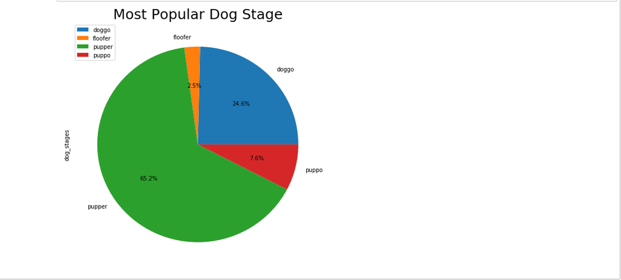

[figure not shown]

1. There is a strong correlation between the favorite count and the retweet count. The higher the number of likes, the higher the number of retweets.

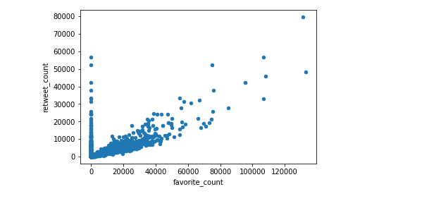